# Homework #8

### Problem #2

Consider the fat dataset, with percentage of body fat, siri, as the response and the other variables, except brozek and density, as potential predictors.

#### Use the models you find to predict the response in the test sample. Make a report on the performance of the models.

```r
library(faraway)
data(fat)

testi = seq(10, 256, by = 10)
train = fat[-testi, -c(1,3)]
test = fat[testi, -c(1,3)]
head(train)
```

```
##   siri age weight height adipos  free neck chest abdom   hip thigh knee ankle
## 1 12.3  23 154.25  67.75   23.7 134.9 36.2  93.1  85.2  94.5  59.0 37.3  21.9
## 2  6.1  22 173.25  72.25   23.4 161.3 38.5  93.6  83.0  98.7  58.7 37.3  23.4
## 3 25.3  22 154.00  66.25   24.7 116.0 34.0  95.8  87.9  99.2  59.6 38.9  24.0
## 4 10.4  26 184.75  72.25   24.9 164.7 37.4 101.8  86.4 101.2  60.1 37.3  22.8
## 5 28.7  24 184.25  71.25   25.6 133.1 34.4  97.3 100.0 101.9  63.2 42.2  24.0
## 6 20.9  24 210.25  74.75   26.5 167.0 39.0 104.5  94.4 107.8  66.0 42.0  25.6
##   biceps forearm wrist
## 1   32.0    27.4  17.1
## 2   30.5    28.9  18.2
## 3   28.8    25.2  16.6
## 4   32.4    29.4  18.2
## 5   32.2    27.7  17.7
## 6   35.7    30.6  18.8
```

```r
summary(train)
```

```
##       siri            age           weight          height          adipos
##  Min.   : 0.00   Min.   :22.0   Min.   :118.5   Min.   :29.50   Min.   :18.10
##  1st Qu.:12.40   1st Qu.:35.5   1st Qu.:157.8   1st Qu.:68.25   1st Qu.:23.05
##  Median :19.30   Median :43.0   Median :176.2   Median :70.25   Median :24.80
##  Mean   :19.18   Mean   :44.8   Mean   :178.6   Mean   :70.17   Mean   :25.36
##  3rd Qu.:25.45   3rd Qu.:54.0   3rd Qu.:196.9   3rd Qu.:72.25   3rd Qu.:27.25
##  Max.   :47.50   Max.   :81.0   Max.   :363.1   Max.   :77.75   Max.   :48.90
##       free            neck           chest           abdom
##  Min.   :105.9   Min.   :31.10   Min.   : 79.3   Min.   : 69.40
##  1st Qu.:130.7   1st Qu.:36.35   1st Qu.: 94.0   1st Qu.: 84.00
##  Median :141.7   Median :38.00   Median : 99.6   Median : 90.90
##  Mean   :143.4   Mean   :37.97   Mean   :100.7   Mean   : 92.40
##  3rd Qu.:153.9   3rd Qu.:39.40   3rd Qu.:105.3   3rd Qu.: 99.15
##  Max.   :240.5   Max.   :51.20   Max.   :136.2   Max.   :148.10
##       hip             thigh            knee           ankle
##  Min.   : 85.00   Min.   :47.20   Min.   :33.00   Min.   :19.10
##  1st Qu.: 95.45   1st Qu.:56.00   1st Qu.:36.90   1st Qu.:22.00
##  Median : 99.20   Median :58.90   Median :38.40   Median :22.70
##  Mean   : 99.85   Mean   :59.37   Mean   :38.55   Mean   :23.07
##  3rd Qu.:103.55   3rd Qu.:62.40   3rd Qu.:39.85   3rd Qu.:23.85
##  Max.   :147.70   Max.   :87.30   Max.   :49.10   Max.   :33.90
##      biceps         forearm          wrist
##  Min.   :24.80   Min.   :21.00   Min.   :15.80
##  1st Qu.:30.25   1st Qu.:27.30   1st Qu.:17.60
##  Median :32.00   Median :28.70   Median :18.30
##  Mean   :32.25   Mean   :28.65   Mean   :18.23
##  3rd Qu.:34.20   3rd Qu.:30.00   3rd Qu.:18.80
##  Max.   :45.00   Max.   :34.90   Max.   :21.40
```

# 1. Linear Regression with all mentioned predictors

```r
lmodFull = lm(siri ~ ., data = train)
mseFull = mean((test$siri - predict(lmodFull, test))^2)
summary(lmodFull)
```

```
##
## Call:
## lm(formula = siri ~ ., data = train)
##
## Residuals:
##     Min      1Q  Median      3Q     Max
## -5.8314 -0.6722  0.1828  0.9150  6.6619
##
## Coefficients:
##               Estimate Std. Error t value Pr(>|t|)
## (Intercept) -12.591885   6.448868  -1.953 0.052193 .
## age           0.007978   0.012320   0.648 0.517983
## weight        0.362999   0.023314  15.570  < 2e-16 ***
## height        0.049026   0.040315   1.216 0.225315
## adipos       -0.514032   0.114074  -4.506 1.09e-05 ***
## free         -0.564773   0.014889 -37.933  < 2e-16 ***
## neck          0.016525   0.089863   0.184 0.854272
## chest         0.120219   0.039590   3.037 0.002694 **
## abdom         0.140108   0.042186   3.321 0.001056 **
## hip           0.006197   0.056101   0.110 0.912148
## thigh         0.195057   0.054460   3.582 0.000424 ***
## knee          0.106637   0.093534   1.140 0.255542
## ankle         0.125118   0.081303   1.539 0.125325
## biceps        0.096199   0.064656   1.488 0.138278
## forearm       0.230775   0.073332   3.147 0.001888 **
## wrist         0.139279   0.206804   0.673 0.501378
## ---
## Signif. codes:  0 '***' 0.001 '**' 0.01 '*' 0.05 '.' 0.1 ' ' 1
##
## Residual standard error: 1.55 on 211 degrees of freedom
## Multiple R-squared:  0.9692, Adjusted R-squared:  0.967
## F-statistic: 442.5 on 15 and 211 DF,  p-value: < 2.2e-16
```

```r
cat("The MSE is ", mseFull)
```

```
## The MSE is  1.280357
```

# 2. Linear Regression with variables selected using AIC

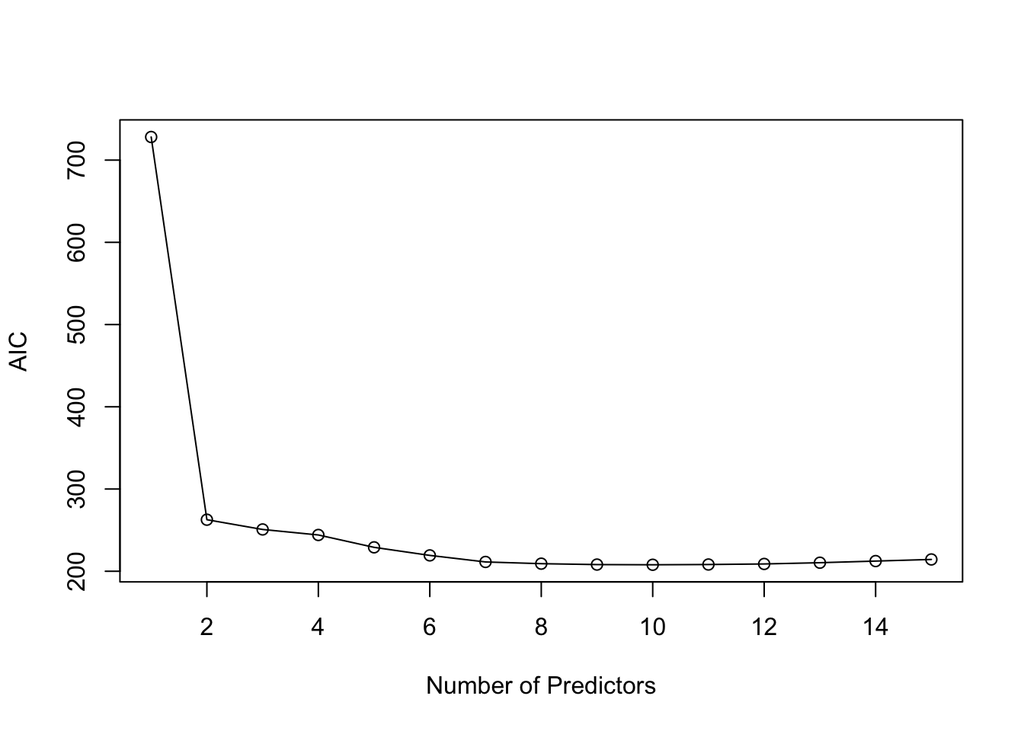

```r
library(leaps)
n = length(train$siri)
b = regsubsets(siri ~ ., data = train, nvmax = 15)
rs = summary(b)
aic = n*log(rs$rss/n) + 2*(2:16)
i = which.min(aic)
plot(aic ~ I(1:15), ylab = "AIC", xlab = "Number of Predictors", type = "o", col = c("black", "red")[as.factor(c(1:(i-1)*0,1,(1:15 - i))*0)])
```

```r
trainAIC = train[, rs$which[i,]]
lmodAIC = lm(siri ~ ., data = trainAIC);
summary(lmodAIC)
```

```
##
## Call:
## lm(formula = siri ~ ., data = trainAIC)
##
## Residuals:
##     Min      1Q  Median      3Q     Max
## -5.7926 -0.6839  0.2371  0.8824  6.8655
##
## Coefficients:
##             Estimate Std. Error t value Pr(>|t|)
## (Intercept) -7.24766    3.94171  -1.839 0.067331 .
## weight       0.36973    0.01994  18.546  < 2e-16 ***
## adipos      -0.57022    0.09459  -6.028 7.09e-09 ***
## free        -0.55965    0.01400 -39.978  < 2e-16 ***
## chest        0.12099    0.03809   3.176 0.001709 **
## abdom        0.15824    0.03908   4.049 7.18e-05 ***
## thigh        0.16140    0.04551   3.546 0.000479 ***
## knee         0.12767    0.08749   1.459 0.145947
## ankle        0.13817    0.07858   1.758 0.080106 .
## biceps       0.11222    0.06317   1.777 0.077055 .
## forearm      0.24281    0.06990   3.474 0.000620 ***
## ---
## Signif. codes:  0 '***' 0.001 '**' 0.01 '*' 0.05 '.' 0.1 ' ' 1
##
## Residual standard error: 1.544 on 216 degrees of freedom
## Multiple R-squared:  0.9687, Adjusted R-squared:  0.9673
## F-statistic: 668.6 on 10 and 216 DF,  p-value: < 2.2e-16
```

```r
testAIC = test[, rs$which[i,]]
mseAIC = mean(((test$siri) - (predict(lmodAIC, test)))^2)
cat("The MSE is ", mseAIC)
```

```
## The MSE is  1.258928
```

# 3. We will find the PC’s and decicde how many to use

```r
s = prcomp(train[, -1], scale = T)
summary(s)
```

```
## Importance of components:
##                          PC1    PC2     PC3     PC4     PC5     PC6     PC7
## Standard deviation     3.072 1.2415 1.04228 0.82869 0.77340 0.60565 0.57145
## Proportion of Variance 0.629 0.1028 0.07242 0.04578 0.03988 0.02445 0.02177
## Cumulative Proportion  0.629 0.7317 0.80414 0.84992 0.88980 0.91425 0.93602
##                            PC8     PC9    PC10    PC11   PC12    PC13    PC14
## Standard deviation     0.52205 0.44467 0.42667 0.35774 0.2765 0.21504 0.19703
## Proportion of Variance 0.01817 0.01318 0.01214 0.00853 0.0051 0.00308 0.00259
## Cumulative Proportion  0.95419 0.96738 0.97951 0.98804 0.9931 0.99622 0.99881
##                           PC15
## Standard deviation     0.13350
## Proportion of Variance 0.00119
## Cumulative Proportion  1.00000
```

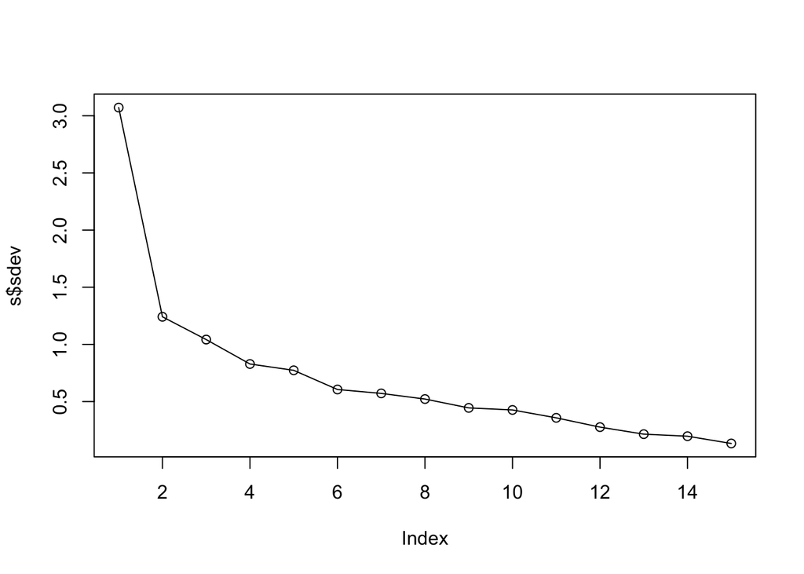

```r
plot(s$sdev, type = "o")  # Use first 10 PC's
```

# Then we are going to fit the PCR model using the first 10 PCs

```r
trainPCR = data.frame(siri = train$siri, s$x[, 1:10]);
lmodPCR = lm(siri ~ ., trainPCR)
summary(lmodPCR)
```

```
##
## Call:
## lm(formula = siri ~ ., data = trainPCR)
##
## Residuals:
##     Min      1Q  Median      3Q     Max
## -6.7344 -1.5599  0.1436  1.6026 13.7149
##
## Coefficients:
##             Estimate Std. Error t value Pr(>|t|)
## (Intercept) 19.18018    0.16528 116.044  < 2e-16 ***
## PC1          1.68153    0.05393  31.180  < 2e-16 ***
## PC2         -3.47334    0.13343 -26.032  < 2e-16 ***
## PC3         -0.99594    0.15893  -6.267 1.97e-09 ***
## PC4          0.20279    0.19989   1.015    0.311
## PC5          1.51306    0.21418   7.064 2.19e-11 ***
## PC6          5.82591    0.27351  21.301  < 2e-16 ***
## PC7          1.74098    0.28988   6.006 7.97e-09 ***
## PC8          0.10819    0.31730   0.341    0.733
## PC9          5.06389    0.37252  13.593  < 2e-16 ***
## PC10        -1.82909    0.38824  -4.711 4.41e-06 ***
## ---
## Signif. codes:  0 '***' 0.001 '**' 0.01 '*' 0.05 '.' 0.1 ' ' 1
##
## Residual standard error: 2.49 on 216 degrees of freedom
## Multiple R-squared:  0.9186, Adjusted R-squared:  0.9148
## F-statistic: 243.7 on 10 and 216 DF,  p-value: < 2.2e-16
```

```r
testPCR = data.frame(siri = test$siri);
mseAIC = mean(((test$siri) - (predict(lmodAIC, test)))^2)
cat("The MSE is ", mseAIC)
```

[output not shown]

```
## The MSE is  1.258928
```

### Problem #3

Use the seatpos data with hipcenter as the response.

#### (a) Fit a model with all eight predictors. Comment on the effect of leg length on the response.

```r
library(faraway)
data(seatpos)

head(seatpos)
```

```
##   Age Weight HtShoes    Ht Seated  Arm Thigh  Leg hipcenter
## 1  46    180   187.2 184.9   95.2 36.1  45.3 41.3  -206.300
## 2  31    175   167.5 165.5   83.8 32.9  36.5 35.9  -178.210
## 3  23    100   153.6 152.2   82.9 26.0  36.6 31.0   -71.673
## 4  19    185   190.3 187.4   97.3 37.4  44.1 41.0  -257.720
## 5  23    159   178.0 174.1   93.9 29.5  40.1 36.9  -173.230
## 6  47    170   178.7 177.0   92.4 36.0  43.2 37.4  -185.150
```

```r
lmod = lm(hipcenter ~ ., data = seatpos)
summary(lmod)
```

```
##
## Call:
## lm(formula = hipcenter ~ ., data = seatpos)
##
## Residuals:
##     Min      1Q  Median      3Q     Max
## -73.827 -22.833  -3.678  25.017  62.337
##
## Coefficients:
##              Estimate Std. Error t value Pr(>|t|)
## (Intercept) 436.43213  166.57162   2.620   0.0138 *
## Age           0.77572    0.57033   1.360   0.1843
## Weight        0.02631    0.33097   0.080   0.9372
## HtShoes      -2.69241    9.75304  -0.276   0.7845
## Ht            0.60134   10.12987   0.059   0.9531
## Seated        0.53375    3.76189   0.142   0.8882
## Arm          -1.32807    3.90020  -0.341   0.7359
## Thigh        -1.14312    2.66002  -0.430   0.6706
## Leg          -6.43905    4.71386  -1.366   0.1824
## ---
## Signif. codes:  0 '***' 0.001 '**' 0.01 '*' 0.05 '.' 0.1 ' ' 1
##
## Residual standard error: 37.72 on 29 degrees of freedom
## Multiple R-squared:  0.6866, Adjusted R-squared:  0.6001
## F-statistic:  7.94 on 8 and 29 DF,  p-value: 1.306e-05
```

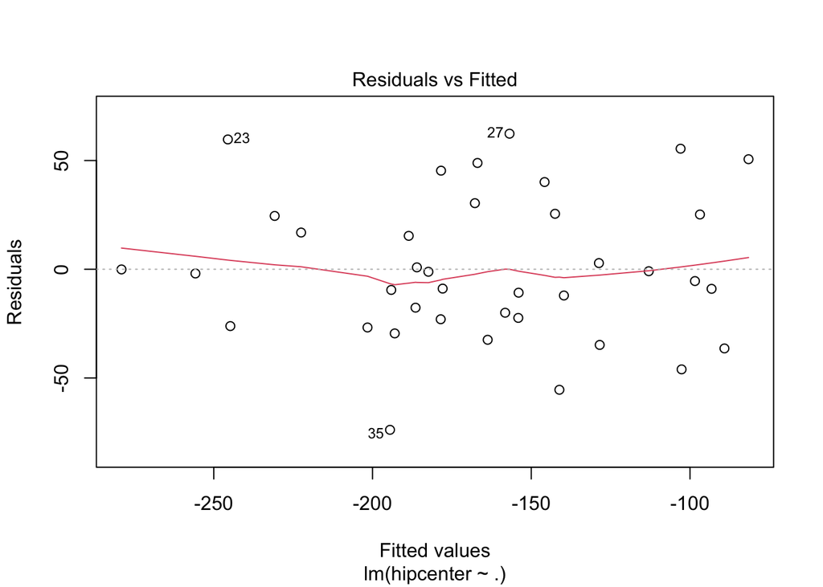

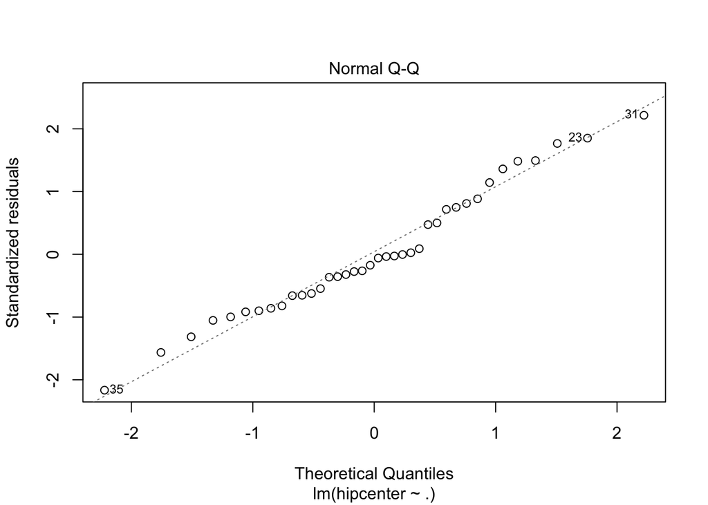

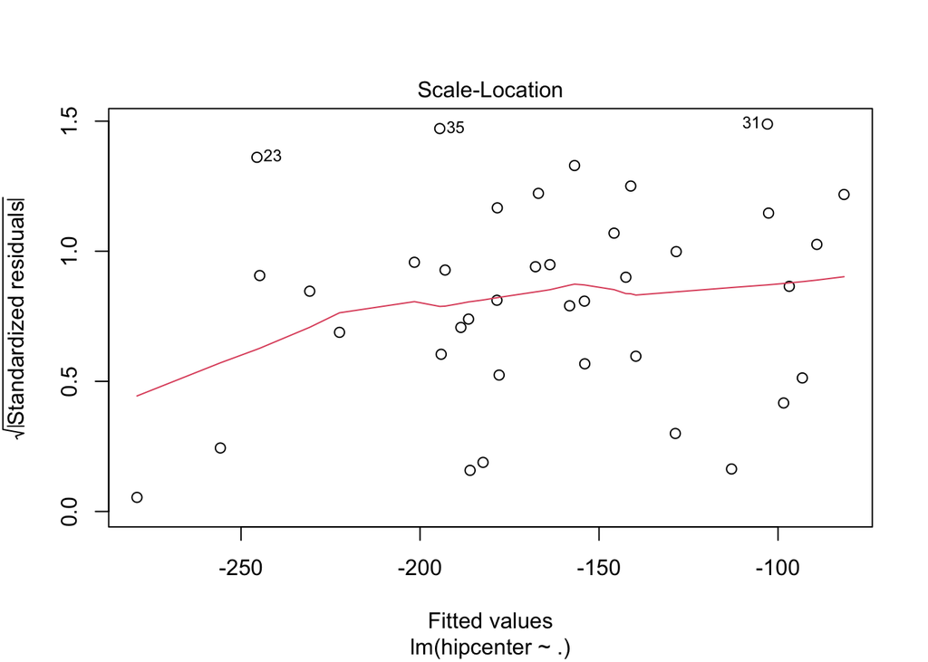

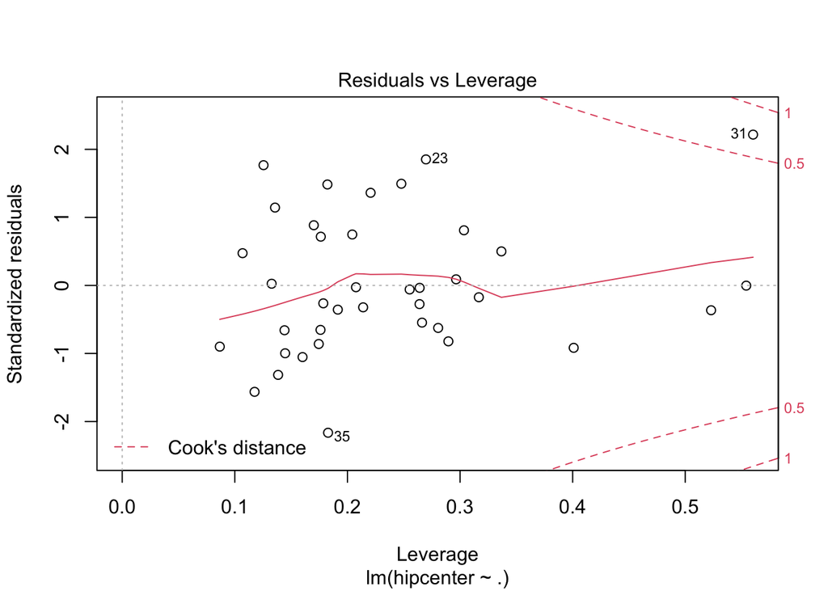

```r
plot(lmod)
```

```r
print("The fit of the model is not that great, though the p-value is small. Leg lengeth apears to have the most effect for all the predictors, if any.")
```

```
## [1] "The fit of the model is not that great, though the p-value is small. Leg lengeth apears to have the most effect for all the predictors, if any."
```